# Görsel Programlama

## AppJar paketinin kurulumu

Ayarlar sekmesi altındaki kutu ikonuna tıklayarak Paket Yöneticisi açılır.

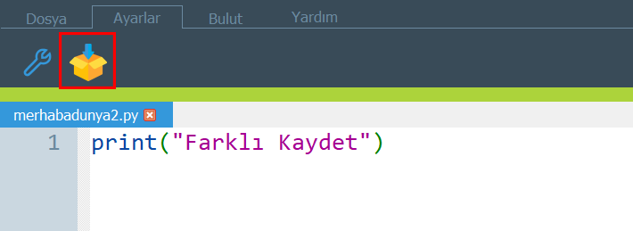

Paket yöneticisine tıklandığında karşınıza kurulu paketleri görebildiğiniz veya yeni paketler kurabildiğiniz bir pencere çıkar.

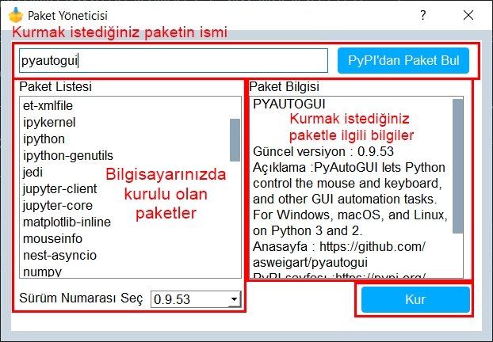

Arama kutusuna AppJar yazıp PyPl’dan Paket Bul butonuna tıklayın.

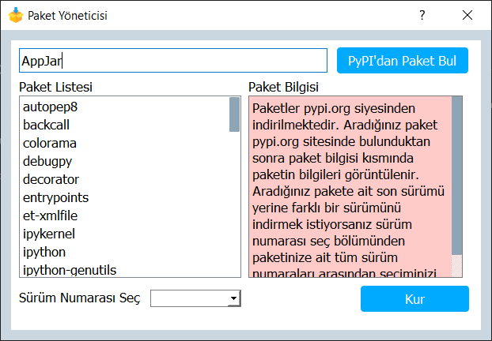

Paket bulunduğunda pencerenin sağ tarafında paketle ilgili bilgileri ve kur butonunu görebilirsiniz.

[figure not shown]

Kur butonuna tıkladığınızda kurulum başlayacaktır. Kurulum bitene kadar bir süre bekleyiniz.

[figure not shown]

Kurulum bittiğinde İndirme başarılı yazan bir pencere çıkacaktır.

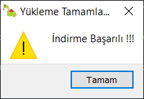

Paket Kullanıma hazır.

## Pencere

### Pencere Oluşturma

Pencere oluşturmak için AppJar kütüphanesinden gui (Görsel kullanıcı arayüzü) sınıfının içe aktarılması gerek. **p = gui()** yazarak p adında bir pencere oluşturabiliriz. gui() sınıfına ait **go()** metodu ise oluşturulan pencereyi başlatır.

**Örnek**

```python
#appJar kütüphanesinden gui sınıfını içe aktar
from appJar import gui

#Sonra pencere objesini oluştur
p = gui()

#Son olarak pencereyi başlat
p.go()
```

### Pencere Boyutu

Oluşturulan bir pencerenin boyutunu ayarlamak için gui() sınıfına ait **setSize()** metodu kullanılır. parametre olarak ilk önce pencerenin eni sonra da boyu aralarına virgül(,) konarak girilir.

**Örnek**

[figure not shown]

```python
from appJar import gui
p = gui()

#Pencerenin en,boy uzunluklarını 300,200 olarak ayarla
p.setSize(300,200)

p.go()
```

### Pencere Başlığı

Oluşturulan bir pencerenin başlığını ayarlamak için gui() sınıfına ait **setTitle()** metodu kullanılır.

**Örnek**

[figure not shown]

```python
from appJar import gui
p = gui()
p.setSize(300,200)

#Pencerenin başlığını 'Başlık' olarak değiştir
p.setTitle("Başlık")

p.go()
```

### Pencere Arkaplan Rengi

Oluşturulan bir pencerenin Arkaplan rengini ayarlamak için gui() sınıfına ait **setBg()** metodu kullanılır. Parametre olarak temel renklerin isimleri ingilizce olarak girilir.

**Örnek**

[figure not shown]

```python
from appJar import gui
p = gui()
p.setSize(300,200)

#Pencerenin arka plan rengini yeşil yap
p.setBg('green')

p.go()
```

## Girdi Araçları

Girdi araçları tıklayarak, sürükleyerek ya da yazarak yapılan kullanıcı etkilişimmlerini yakalamak için kullanılır. Genelde 3 temel fonksiyon vardır.

- ADD : Aracı ekler.
- GET : Aracın mevcut durumunu ya da içeriğini alır, kaydeder.
- SET : Aracın içindekini değiştirir.

Genel olarak önce bu üçünden biri yazılır hemen ardında ise ilgili aracın adı gelir.

### Buton

Buton eklemek için gui() sınıfına ait **addButton()** metodu kullanılır. İki parametre alır, önce butonun başlığı girilir ardından butona tıklandığında çağıralacak fonksiyon.

**Örnek**

[figure not shown]

```python
def press():#Butona tıklandığı zaman çağrılacak fonksiyon
    #'Tıklandı' diye bir mesaj yazdır
    print('Tıklandı')

from appJar import gui
p = gui()
p.setSize(300,200)

#'Buton' başlıklı bir buton ekle ve
#Bu butona her tıklandığında 'press' fonksiyonunu çalıştır
p.addButton('Buton', press)

p.go()
```

Butona 3 defa tıklandığında alınacak olan çıktı.

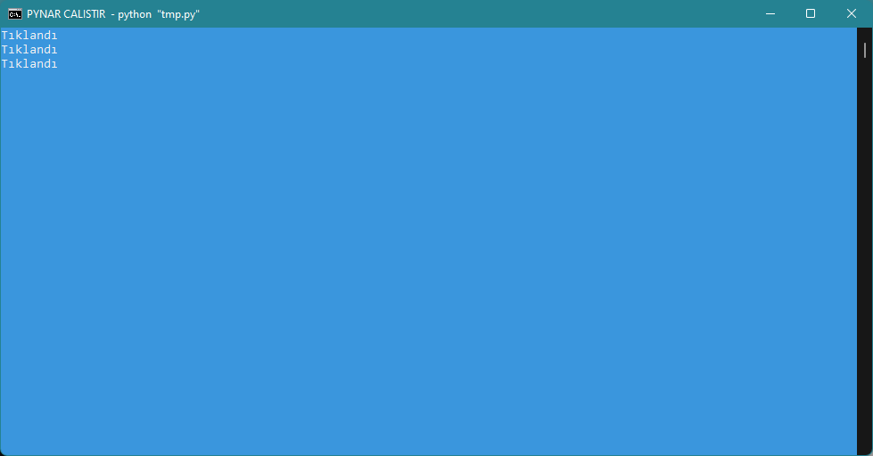

### Metin Kutusu

Metin kutusu eklemek için gui() sınıfına ait **addEntry()** metodu kullanılır. Metin kutusuna girilen bilgiyi almak için ise **getEntry()** metodu kullanılır.

[figure not shown]

```python
from appJar import gui

def press():#Butona tıklandığı zaman çağrılacak fonksiyon
    #'Metin' başlıklı metin kutusundaki metni yazdır.
    print(p.getEntry('Metin'))

p = gui()
p.setSize(300,200)

#'Metin' başlıklı bir metin kutusu oluştur.
p.addEntry('Metin')

p.addButton('Buton', press)
p.go()
```

Metin kutusuna ‘Pynar’ yazdıktan sonra butona tıklanırsa alınacak çıktı.

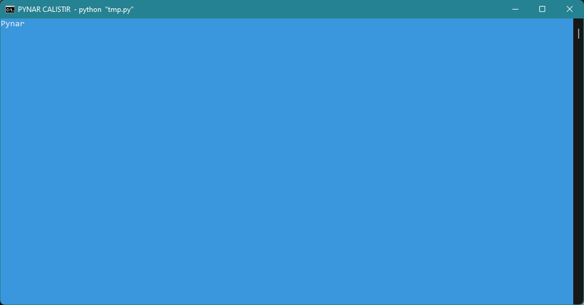

### Çok Satırlı Metin Kutusu

Çok metin kutusu eklemek için gui() sınıfına ait **addTextArea()** metodu kullanılır. Metin kutusuna girilen bilgiyi almak için ise **getTextArea()** metodu kullanılır.

[figure not shown]

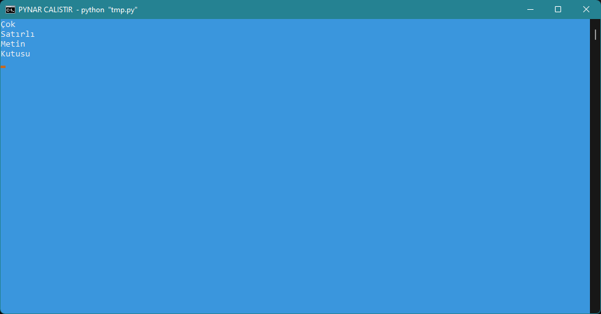

```python
from appJar import gui

def press():#Butona tıklandığı zaman çağrılacak fonksiyon
    #'Metin' başlıklı çok satırlı metin kutusundaki metni yazdır.
    print(p.getTextArea('Metin'))

p = gui()
p.setSize(300,200)

#'Metin' başlıklı bir çok satırlı metin kutusu oluştur.
p.addTextArea('Metin')

p.addButton('Buton', press)
p.go()
```

### Seçenek Düğmesi

Seçenek Düğmesi eklemek için gui() sınıfına ait **addRadioButton()** metodu kullanılır. Parametre olarak önce hangi başlıkla ilgii bir seçim olduğu girilir ardından ise seçeneğin adı girilir. Seçenek düğmelerinden seçilen bilgiyi almak için ise **getRadioButton()** metodu kullanılır. parametre olarak ise hangi başlıkla ilgili seçim isteniyorsa onun başlığı girilir.

[figure not shown]

```python
from appJar import gui

def press():#Buton tıklanınca çağrılacak olan fonksiyon
    print(p.getRadioButton('harf'))#Seçilen düğmeyi çıktı al

p = gui()
p.setSize(300,200)

#Seçenek düğmeleri ekleme.
#'Harf' başlıklı A, B, ve C seçenekleri ekle.
p.addRadioButton('harf', 'A')
p.addRadioButton('harf', 'B')
p.addRadioButton('harf', 'C')

p.addButton('Buton', press)
p.go()
```

Seçim yapılıp butona tıklandıktan sonraki çıktı.

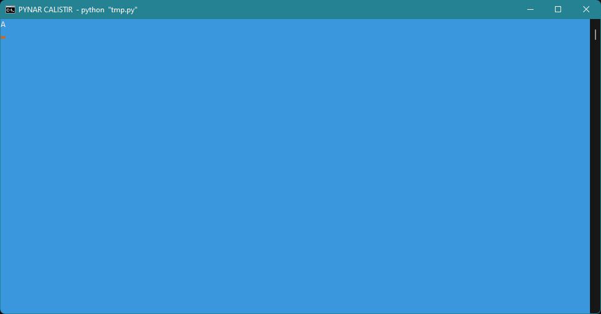

### Onay Kutusu

Onay kutusu eklemek için gui() sınıfına ait **addCheckBox()** metodu kullanılır. Kutucuk işaretli ise True işaretli değil ise False döndürür.

[figure not shown]

```python
from appJar import gui

def press():#Butona tıklanınca çağrılacak fonksiyon
    #Onay başlıklı onay düğmesi şıklıysa 'True', yoksa 'False' yazdır
    print(p.getCheckBox('Onay'))

#Pencereyi oluştur
p = gui()
p.setSize(300,200)

#'Onay' başlıklı bir onay düğmesi oluştur
p.addCheckBox('Onay')

p.addButton('Buton', press)
p.go()
```

Kutuyu işaretlemeden butona tıklandığında alınacak çıktı.

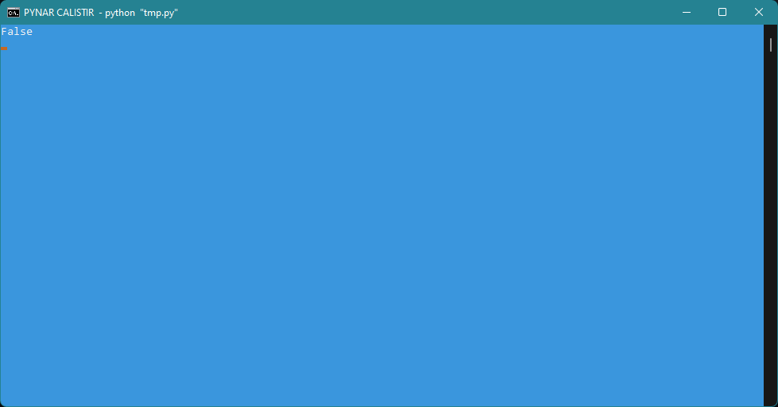

### Seçenek Kutusu

Seçenek kutusu eklemek için gui() sınıfına ait **addOptionBox()** metodu kullanılır.

[figure not shown]

```python
from appJar import gui

def press():#Buton tıklanınca çağrılacak olan fonksiyon
    #'Seçenekler' başlıklı seçenek kutusundaki
    #seçilen ögeyi çıktı al
    print(p.getOptionBox('Seçenekler'))

p = gui()
p.setSize(300,200)

#'Seçenekler' başlıklı bir seçenek kutusu oluştur
#İkinci argümanda kutuda yer alacak değerler bulunmakta
#Bu değerlerden '-' ile başlayıp bitenler ayırma işlevi gördüğünden seçilemez
p.addOptionBox('Seçenekler', ['- Meyveler -', 'Elma', 'Portakal',
'Armut', '- Hayvanlar -', 'Köpek', 'Kedi', 'Tavşan'])

p.addButton('Buton', press)
p.go()
```

Kutuyu tıklanınca açılan menüden portakal seçildikten sonra butona basıldığında alınan çıktı.

[figure not shown]

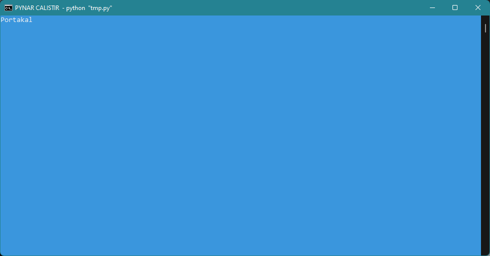

### Spin Kutusu

Spin kutusu eklemek için gui() sınıfına ait **addLabelSpinBox()** metodu kullanılır. Spin kutusu ok tuşları yardımı ile seçenekler arasında dolaşabileceğiniz bir kutudur. Aynı zamanda ilgili seçeneği Kutuya elle de girebilirsiniz. Eğer girilen seçenek kutuda yoksa kutu boş kalacaktır. Belli bir sayı aralığında seçimler isteniyorsa **addLabelSpinBoxRange()** metodu kullanılır.

[figure not shown]

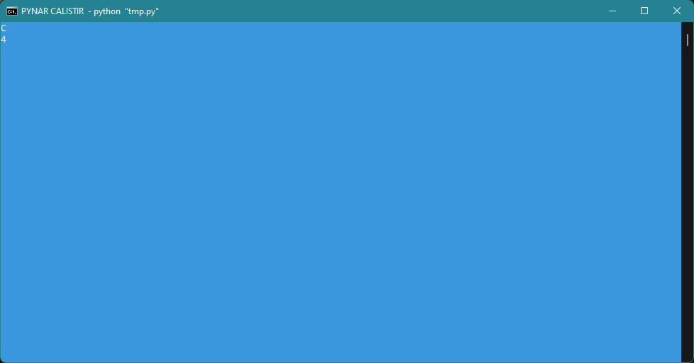

```python
from appJar import gui

def press():#Buton tıklanınca çağrılacak olan fonksiyon
    #'Seçenekler' ve 'Numaralar' başlıklı spin
    #kutularında seçilen ögelerin çıktısını al
    print(p.getSpinBox('Seçenekler'))
    print(p.getSpinBox('Numaralar'))

p = gui()
p.setSize(300,200)

#'Seçenekler' başlıklı ve 'A','B','C','D' değerleri bulunan Spin kutusu ekle.
p.addLabelSpinBox('Seçenekler', ['A', 'B', 'C', 'D'])

#'Numaralar' başlıklı ve içerisinde 1'den 10'a kadar sayılar olan Spin kutusu ekle.
p.addLabelSpinBoxRange('Numaralar', 1, 10)

p.addButton('Buton', press)
p.go()
```

### Liste Kutusu

Liste kutusu eklemek için gui() sınıfına ait **addListBox()** metodu kullanılır.

[figure not shown]

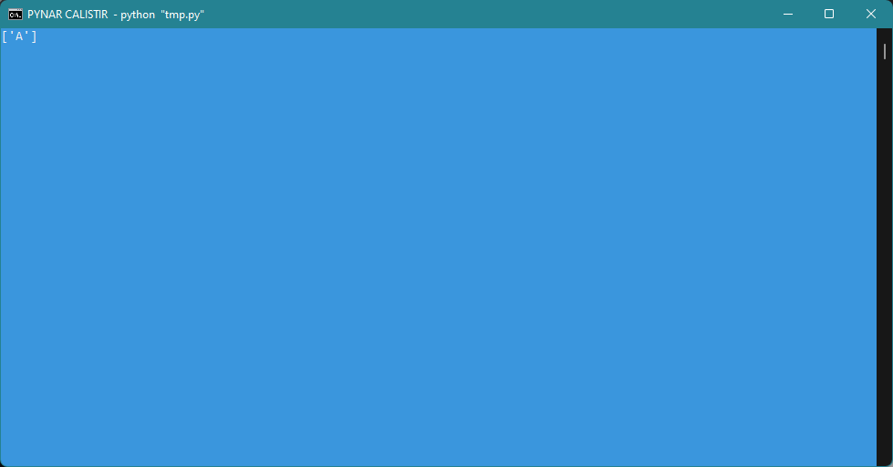

```python
from appJar import gui

def press():#Butona tıklandığı zaman çağrılacak fonksiyon
    #'Liste' başlıklı liste kutusundaki seçilen ögeyi yazdır.
    print(p.getListBox('Liste'))

p = gui()
p.setSize(300,200)

#Liste isimli ve 'A,B,C,D' içerikli bir liste kutusu oluştur
p.addListBox('Liste', ['A','B','C','D'])

p.addButton('Buton', press)
p.go()
```

### Çoklu Liste Kutusu

Çoklu liste kutusu eklemek için gui() sınıfına ait **addListBox()** metodu kullanılır. Fakat çoklu seçim özelliğini etkinleştirmek için **setListBoxMulti()** metodu kullanılır.

```python
from appJar import gui

def press():#Butona tıklandığı zaman çağrılacak fonksiyon
    #'Liste' başlıklı liste kutusundaki seçilen ögeyi yazdır.
    print(p.getListBox('Liste'))

p = gui()

#Liste isimli ve 'A,B,C,D' içerikli bir liste kutusu oluştur
p.addListBox('Liste', ['A','B','C','D'])

#'Liste' başlıklı liste kutusunu çoklu seçimli hale getir.
p.setListBoxMulti('Liste', multi = True)

p.addButton('Buton', press)
p.go()
```

‘CTRL’ tuşuna basılı tutarak birden fazla seçim yapabilirsiniz.

[figure not shown]

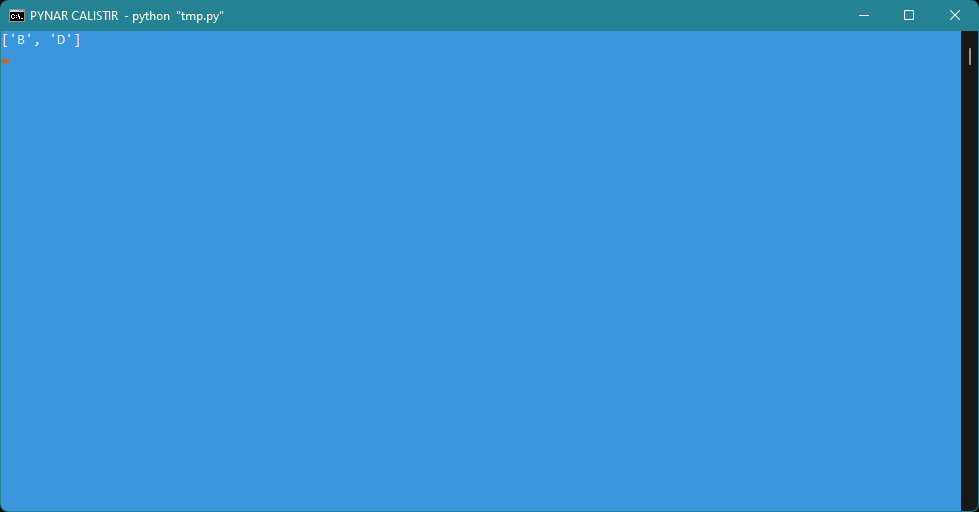